# Tidyclust by Team Tibble

Yasemin Tekin, Michael Schaar, Julian Bouchard

# Introduction

### Package

- Tidyclust
  - Tidyclust is a package in R that is designed for clustering and visualizing high-dimensional datasets. The interface is clean, simple and can perform a variety of different clustering algorithms such as hierarchical clustering, spectral clustering, k-means clustering, etc. Tidyclust is designed and implemented as an extension of the tidyverse and offers a collection of data preprocessing, clustering algorithms, and visualization techniques to enhance user experience when working with elaborate datasets.

[figure not shown]

# What are clustering algorithms?

- Clustering algorithms are an unsupervised machine learning technique that can be used to group similar data points into clusters based on their features or characteristics. The goal of clustering is to find patterns and structure in the data that can help us understand the underlying distribution and relationships between data points. We can use this knowledge to draw accurate inferences and guide our decision making process. Some of the most common clustering methods include k-means clustering, hierarchical clustering, density-based clustering, model-based clustering, and spectral clustering. Clustering is a fundamental concept in data analysis that has a wide range of applications in fields such as biology, economy, marketing, and healthcare.

# Why are clustering algorithms used?

- Clustering algorithms have a wide range of real world applications. They can help us recognize important patterns that encourage us to make accurate predictions and decisions. One interesting application is disease outbreak detection. Clustering algorithms can be used to analyze health related data and recognize patterns that may indicate an outbreak or epidemic. Having the power to predict something that can potentially save millions of lives is powerful and worth understanding. Some other applications include climate change mitigation, sustainable energy planning, wildlife conservation and more.

# K-means Clustering

- K-means clustering is a common unsupervised machine learning algorithm used to group data points into distinct clusters based on certain similarities. Diving deeper, the k-means algorithm works by repeatedly assigning each data point to a cluster based on the mean of the data points in that specific cluster. The “k” stands for the number of clusters that must be identified. This algorithm has applications in many fields such as data science, computer science, bioinformatics, marketing, etc. It has a wide range of data science applications including customer segmentation, image segmentation, gene expression analysis, and anomaly detection. Unfortunately, there are a few limitations with this algorithm such as its sensitivity to outliers and difficulty evaluating non-spherical clusters.

# Package Description

- Tidyclust is derived from the tidyverse and uses a variety of data processing, clustering, and visualization techniques to help users tackle complex datasets. It allows users to perform clustering on numeric and categorical data. A few of the clustering algorithms that are included in the tidyclust package include k-means, hierarchical, and spectral clustering. Additionally, tidyclust includes a variety of different methods used for preprocessing data such as scaling and dimensionality reduction. These methods can be helpful to users that wish to identify patterns in their data. Tidyclust provides users with a set of visualization tools that can be used to translate their clustering results. Some of the visualizations included are scatter plots, dendrograms, and heatmaps. When it comes to working with vast and complex datasets, tidyclust can be a reliable option for researchers and analysts all across the board.

# Author’s

- Tidyclust was developed by Emil Hvitfeldt, Kelly Bodwin, and Posit Software, PBC.
- Emil Hvitfeldt is a data scientist and software developer that has made many contributions in the R programming language and data science community. Emil is a member of the R-Ladies global team which is an organization that promotes gender diversity in the R community.
- Kelly Bodwin Ph.D is a statistician and data scientist who currently teaches as an assistant professor in the statistics department at Cal Poly, San Luis Obispo. Her research interests include data mining, machine learning, statistical computing, and more.
- Posit Software, PBC is dedicated to creating open-source software to help individuals, teams, and enterprises with data science.

# Release Date

- Tidyclust was released to the public on CRAN (Comprehensive R Archive Network) on August 28, 2019 so it is still fairly new.

# Maintinence

- Since the tidyclust package is still in development major changes are expected and new features may be added.
- Updates include performance optimization, bug patches, and more.
- The latest version of tidyclust that’s available is version 0.1.2.
- All bugs can be referenced and monitored here https://github.com/tidymodels/tidyclust/issues.

# Licensing

- The tidyclust package is currently licensed under the MIT license.
- The MIT license is a permissive open-source software license, originating at the Massachusetts Institute of Technology, that permits the use of tidyclust for both commercial and non-commercial use with very few restrictions.

# Documentation and Additional Recources

- Tidyclust has an official reference manual that can be found here https://cran.r-project.org/web/packages/tidyclust/tidyclust.pdf .
- The documentation provides a detailed overview of the tidyclust package as well as its capabilities.
- It’s a valuable resource that is available to help users learn more about the package.
- The documentation is regularly maintained by Emil Hvitfeldt to reflect any updates that have occurred in the package itself.

# Mini Case Study

- We decided that the best way to explain tidyclust’s k-means clustering algorithm would be to perform it ourselves on the penguins data set used earlier in the course. ### Dataset: Penguins
- The penguins dataset is a popular dataset in R that contains various measurements that pertain to three different species of penguins: Adelie, Chinstrap, and Gentoo.

# Goal

- We wish to learn more about certain bill dimensions in females (depth and length in mm) and which features seem to be most prevalent for a given species. We must assume that we begin this study with no information regarding penguin species. Using the k-means clustering algorithm we should be able to group certain bill observations and map them correctly to the according species. By the end of this study, and with the help of the tidyclust package’s k-means clustering algorithm, we hope to obtain a better understanding of the average or typical female bill attributes as they relate to certain species of penguin.

# Possible Questions to Explore

- How do bill dimensions of female penguins vary across different species?
- Which dimensions are most indicative of a particular species?
- Can k-means clustering accurately group female penguins according to species based on their bill attributes?

# K-Means Clustering - Theory

#### Initialization

- Choose *k* random data points as the initial centroids

#### Step 1: Assignment

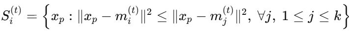

- Assign each data point to its nearest centroid

#### Step 2: Update

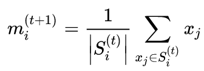

- Update centroids by re-calculating their means

# K-Means Clustering - Visualization

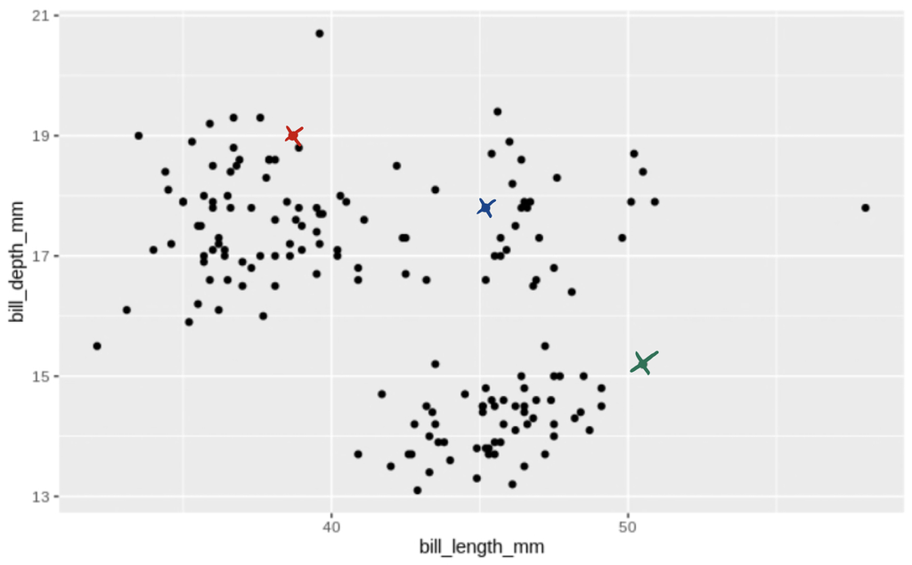

# K-Means Clustering - Visualization

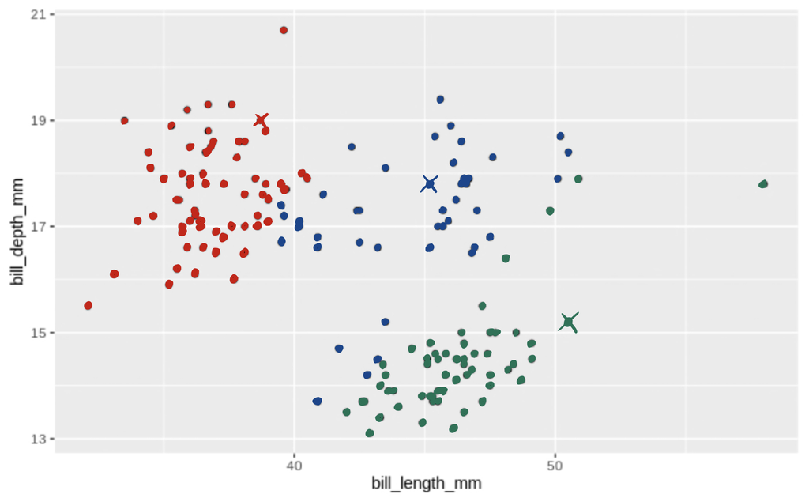

# K-Means Clustering - Visualization

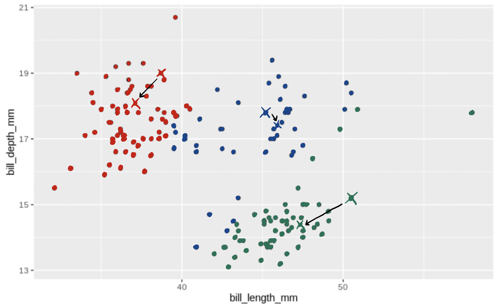

# K-Means Clustering - Visualization

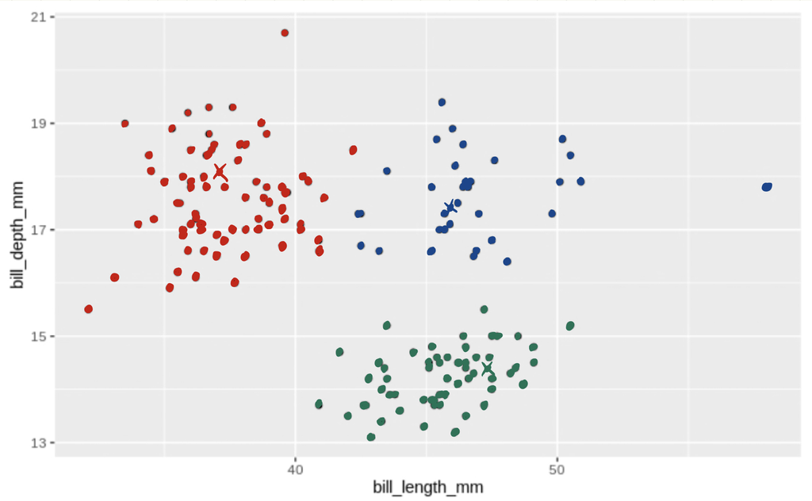

# K-Means Clustering - Pros and Cons

### Pros

- Simple
- Fast (on average)

### Cons

- No guarantee for global optimum
- Sensitive to outliers
- Sensitive to cluster initialization
- Need to determine *k*

# Clustering using tidyclust - Setting up the model

- Follows the tidymodels scheme

In class we discussed linear models using tidymodels:

```r
# code taken from lab04
m_bty <- linear_reg() |>
  set_engine("lm") |>
  fit(score ~ bty_avg, data = evals)
```

Now we apply the same structure with tidyclust:

```r
c_bills <- k_means(num_clusters = 3) |>
  set_engine("ClusterR") |>
  fit(~ bill_depth_mm + bill_length_mm, data=bills)
```

# Clustering using tidyclust - Extracting Results

```r
results <- c_bills |>
  extract_cluster_assignment()
```

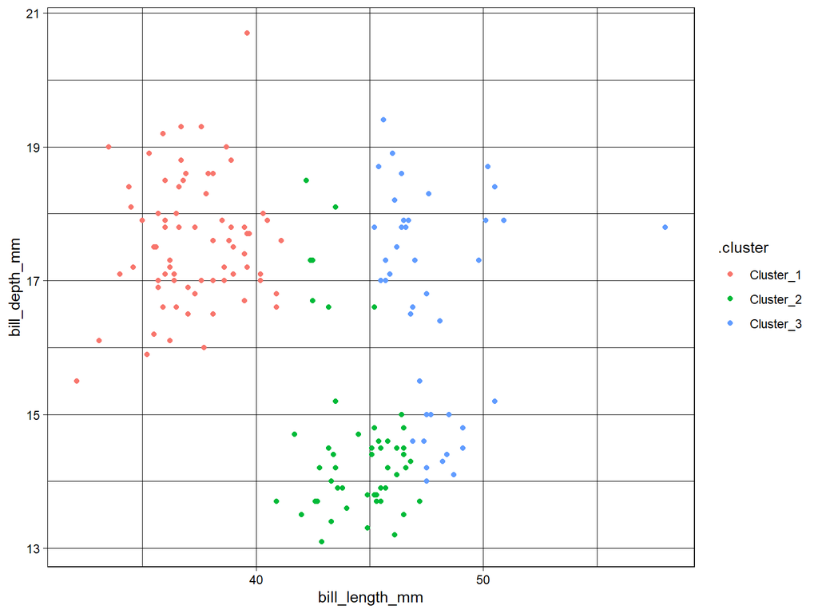

# Clustering using tidyclust - Extracting Centroids

```r
centroids <- c_bills |>
  extract_centroids()
```

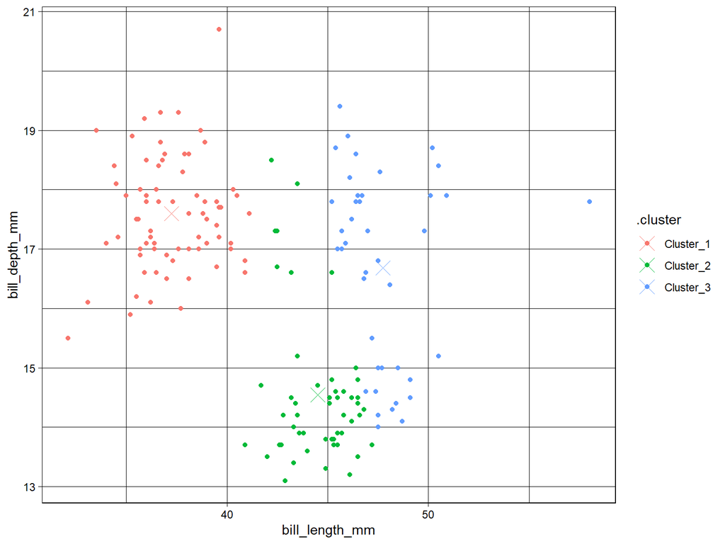

# Clustering using tidyclust - Predicting Data

```r
new_pingu <- tibble(bill_length_mm = c(35), bill_depth_mm = c(16))

c_bills |>
  predict(new_pingu)
```

```
## # A tibble: 1 × 1
##   .pred_cluster
##   <fct>
## 1 Cluster_1
```

# Other Applications of Clustering Algorithms

Cluster analysis can be applied to many other industries and real life situations such as:

-Retail marketing

-Streaming services

-Health Insurance

Example: Using Tidyclust to curate a tailored to taste wedding playlist based on pre-existing version

Author: Mark Rieke (R enthusiast)

Packages used: Tidymodels, Tidyclust, Spotifyr

# Background Information

### Useful functions

get_user_playlists() - access user information

get_playlist_tracks() - pull songs and existing playlists

get_track_audio_features() - identify different features of the songs

### Selecting variables

Energy and valence(positivity) of tracks to use in cluster analysis

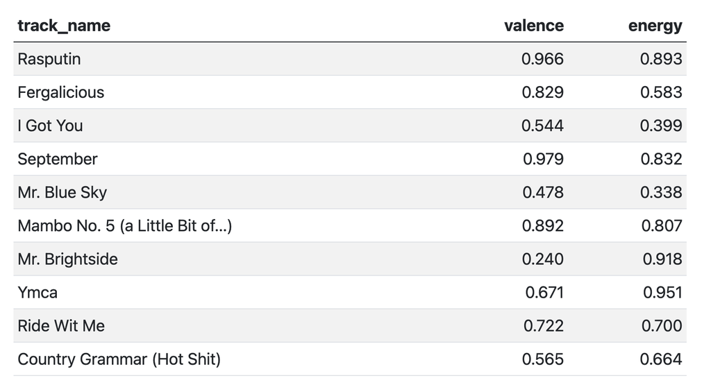

# Plotting

Graphing without cluster analysis (Using ggiraph)

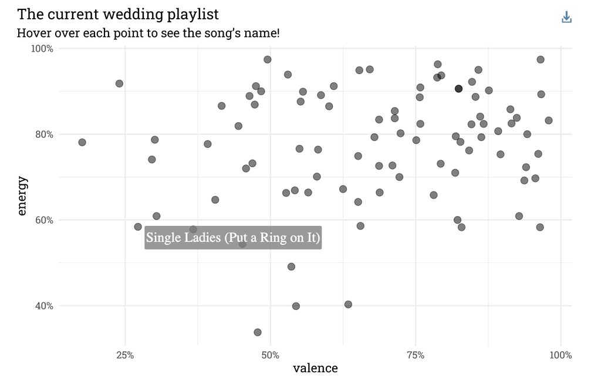

# Utilizing Tidyclust

Graphing using Tidyclust and fitting with k_means(num_clusters = 3) and fitting with valence + energy taken into account

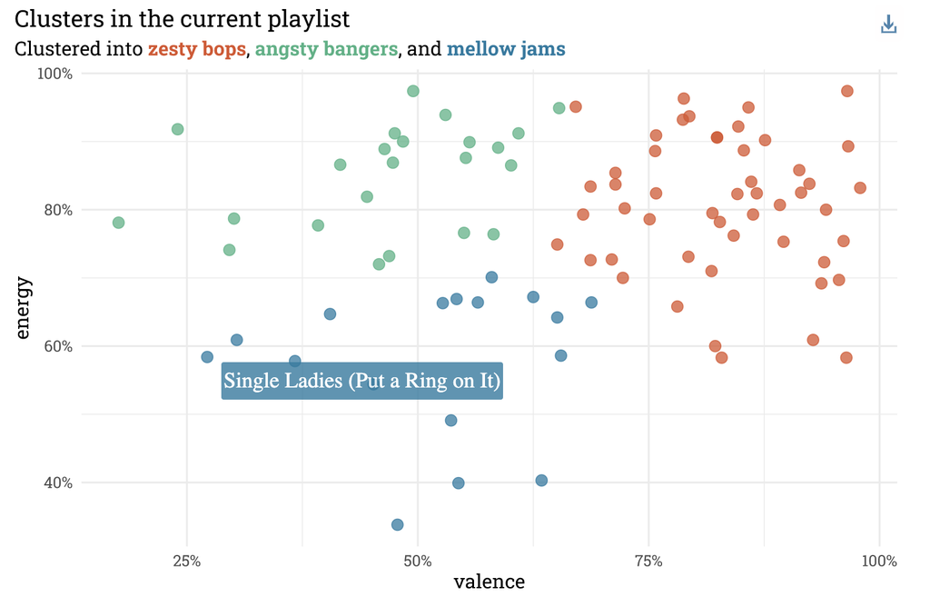

# Assigning new songs to existing clusters

Next, new songs belonging to top playlists are pulled and assigned to respective cluster they fit with based on valance and energy

Cluster analysis plot for new songs

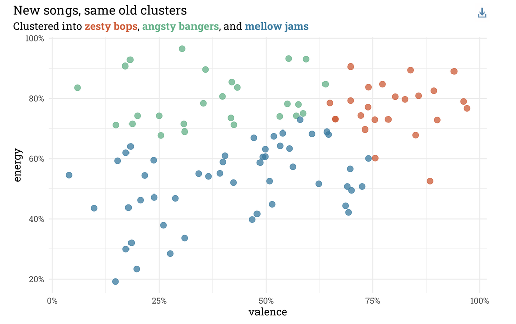

# Checking if the predictions fit

Listing top songs that have a higher “vibe” and predicted to fit with current playlist

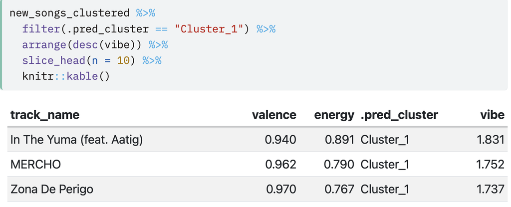

# Tidymodels vs Tidyclust

Main distinctions:

- models with outcomes vs models without outcomes
- clearly defined predict() vs no clearly defined predict()
- easy estimation of performance vs no clear answer

# Conclusion

Tidyclust - a powerful analysis tool with numerous application ranging from data science to real life situations allowing for enhanced visual graphing by creating a unified interface using same style as ‘parsnip’

Key features:

- group data based on certain similarities
- help predict and recognize patterns in complex datasets
- tidyverse compatible